# assign4

Shaoyi Zhang

May 24, 2016

```r
setwd("/Users/Shawn/Desktop/PSTAT 231/PSTAT-231/assign4")
set.seed(2)
library(data.table)
#food.data = data.table()
food.data = read.table("food.txt",header = T,row.names = 1)
#for (i in 2:6){
#  food.data[,c(i)] = as.numeric(food.data[,c(i)])
#}
```

If we choose to have 2 clusters:

```r
km.2 = kmeans(food.data[2:ncol(food.data)], centers = 2, iter.max = 10, nstart = 20)

# the centroids
km.2$centers
```

```
##    Protein       Fat  Calcium     Iron
## 1 19.08333 14.208333  21.0000 2.470833
## 2 18.33333  7.666667 227.6667 1.666667
```

```r
# The size of each center
km.2$size
```

```
## [1] 24  3
```

```r
# The ratio of between-SS/total-SS
km.2$betweenss/km.2$totss
```

```
## [1] 0.7031662
```

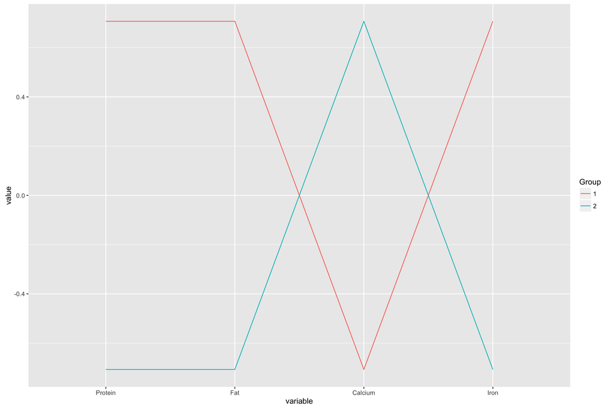

```r
centers = as.data.table(km.2$centers)
centers[,Group:=as.factor(c(1,2))]
library(GGally)
gpd <- ggparcoord(data = centers, columns = 1:4, groupColumn = 5)
gpd
```

Group 1 has high Protein, Fat and Iron, but Low Calcium.

Group 2 has High Calcium, but low Protein, Fat and Iron.

```r
# Group membership
km.2$cluster
```

```
##        Braised beef           Hamburger          Roast beef
##                   1                   1                   1
##           Beefsteak         Canned beef     Broiled chicken
##                   1                   1                   1
##      Canned chicken          Beef heart      Roast lamb leg
##                   1                   1                   1
## Roast lamb shoulder          Smoked ham          Pork roast
##                   1                   1                   1
##       Pork simmered         Beef tongue         Veal cutlet
##                   1                   1                   1
##      Baked bluefish           Raw clams        Canned clams
##                   1                   1                   1
##     Canned crabmeat       Fried haddock    Broiled mackerel
##                   1                   1                   1
##     Canned mackerel         Fried perch       Canned salmon
##                   2                   1                   2
##     Canned sardines         Canned tuna       Canned shrimp
##                   2                   1                   1
```

From the cluster membership, we noticed that Group 2 are all Canned fish. Since seafood tends to have high Calcium, our grouping is reasonable. But there are still many “fish” categorized in Group 1 which are mostly beef/lamb/chicken.

Then, if we choose to have 3 clusters:

```r
km.3 = kmeans(food.data[2:ncol(food.data)], centers = 3, iter.max = 10, nstart = 20)

# the centroids
km.3$centers
```

```
##    Protein      Fat   Calcium     Iron
## 1 22.00000  9.00000 367.00000 2.500000
## 2 14.80000  3.40000 114.00000 3.300000
## 3 19.85714 16.09524  11.90476 2.157143
```

```r
# The size of each center
km.3$size
```

```
## [1]  1  5 21
```

```r
# The ratio of between-SS/total-SS
km.3$betweenss/km.2$totss
```

```
## [1] 0.9328222
```

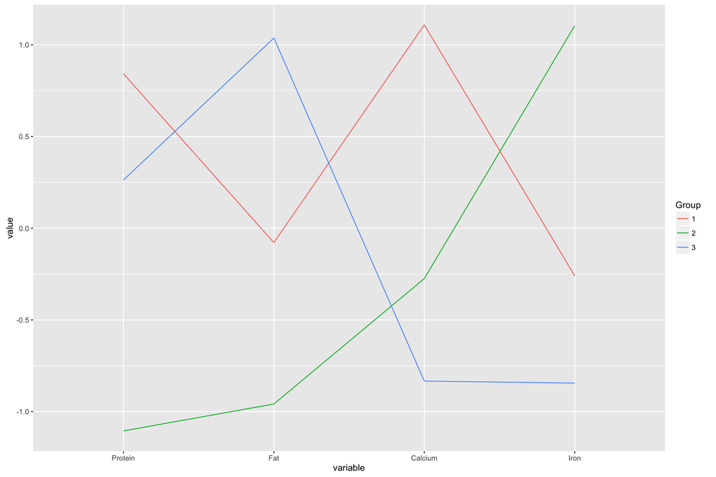

```r
centers = as.data.table(km.3$centers)
centers[,Group:=as.factor(c(1,2,3))]
library(GGally)
gpd <- ggparcoord(data = centers, columns = 1:4, groupColumn = 5)
gpd
```

Group 2 have high Iron, medium Calcium, but low Protein and Fat.